# Badanie rozkładu statystyk służących do weryfikacji hipotez 𝛼 = 𝑎0 i 𝛽 = 𝑏0

Olga Sieradzan, Aleksandra Talaga, Justyna Sarkowicz

2024-03-22

# Wstęp

Celem projektu jest zbadanie rozkładów statystyk, które służą do weryfikacji hipotez (𝛼 = 𝑎0 i 𝛽 = 𝑏0) w jednoczynnikowym modelu regresji liniowej.  
**Przebieg badania:** Z rozkładu jednostajnego wylosowano wartości zmiennych objaśniających (x1 … xn) oraz ze standardowego rozkładu normalnego wylosowano wartości składników losowych ( ε1 … εn). Posortowano xi, a następnie pierwszą połowę składników losowych zgodnie z poleceniem przemnożono przez odpowiednie sigma, a drugą przez k * sigma, aby wyeliminować homoskedastyczność składnika losowego. Następnie zdefiniowano równanie `yi = a0 + b0*xi + εi`, gdzie y jest zmienną objaśnianą w naszym modelu, a0 i b0 to wybrane przez nas parametry. Za pomocą metody najmniejszych kwadratów oszacowano wartości estymatorów modelu `y = α + βx` (gdzie α to estymator wyrazu wolnego, β to estymator współczynnika stojącego przy x). Dla tak przygotowanych estymatorów obliczono odpowiednie statystyki służące do weryfikacji hipotez 𝛼 = a0 i 𝛽 = b0. Obliczono je krzystając ze wzorów `t = (αi - ai)/D(ai)` dla alfa oraz `t = (βi - bi)/D(bi)` dla beta (gdzie D to błąd standardowy estymatora i-tego patametru). Projekt skupia się na zbadaniu rozkładów powyższych statystyk i odpowiedzeniu na pytania, jak poszczególne parametry wpływają na ich rozkłady.  
W badaniu przyjęto następujące wartości parametrów:

- **max = 20, 200** - górna granica dla rozkładu jednostajnego, z którego wylosowane zostały zmienne objaśniające) W badaniach więc losujemy zmienne z rozkładu jednostajnego na przedziałąch [0, 20] oraz [0, 200]
- **a = 1, 10** - wyraz wolny w modelu
- **b = 5, 20** - współczynnik stojący przy x w modelu
- **n = 10, 20, 50, 100, 500** - liczba wylosowanych zmiennych
- **k = 0.1, 1, 5, 10** - parametr przez który przmnażamy składniki losowe w drugiej połowie
- **simga = 1, 10** - odchylenie standardowe składników losowych

# Wizualizacja zmiennej objaśnianej y

W celu lepszego przedstawienia, jak modyfikacje wpłynęły na badane rozkłady, postanowiono najpierw dokonać kilku przykładowych wizualizacji, prezentujących zmienną objaśnianą y, w zależności od różnych przyjmowanych parametrów. Wszystkie wizualizacje dokonano dla przypadku, kiedy zmienne objaśniające losowane są z przedziału [0,20] oraz dla a = 1 i b = 5, aby łatwiej zauważyć różnice przy zmianie parametrów sigma oraz k.

**Przypadek 1**

- sigma = 1
- k = 0.1

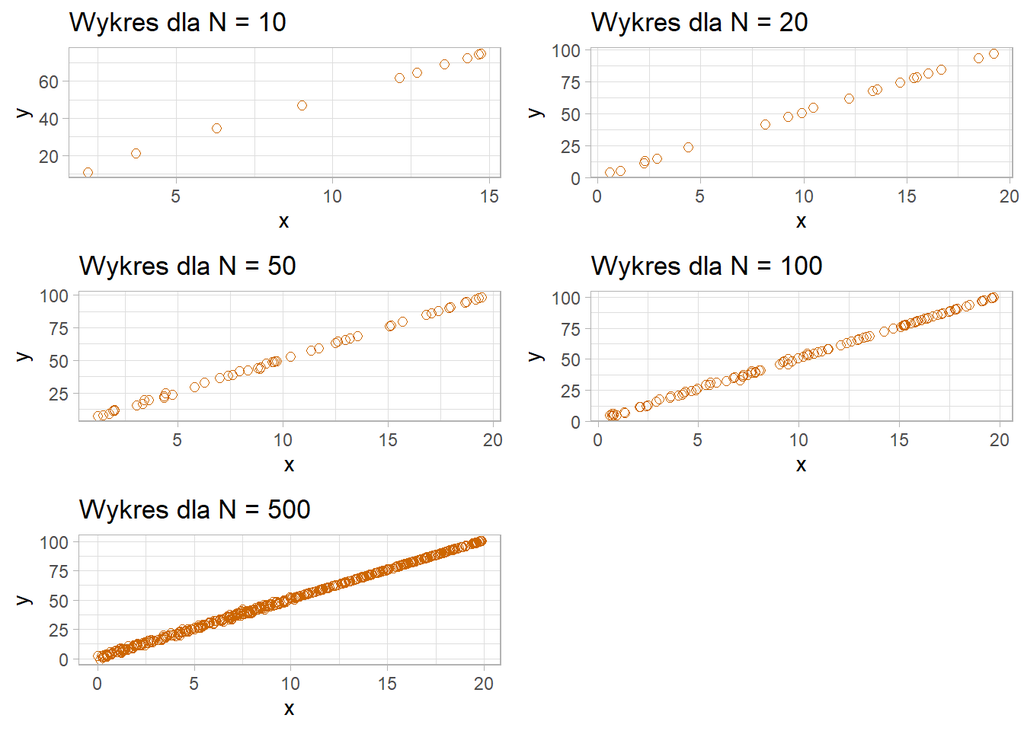

Obserwacje na wykresie układają się bardzo regularnie w linię prostą. Ponieważ odchylenie standardowe jest małe, obserwacje nie odchylają się znacząco od prostej. Bardzo małe jest również k, przez które została przemnożona wariancja dla epsilonów w drugiej połowie obserwacji. Z tego powodu nie widać gołym okiem rzadnej różncy między obserwacjami z pierszej i z drugiej połowy.

**Przypadek 2**

- sigma = 10
- k = 1

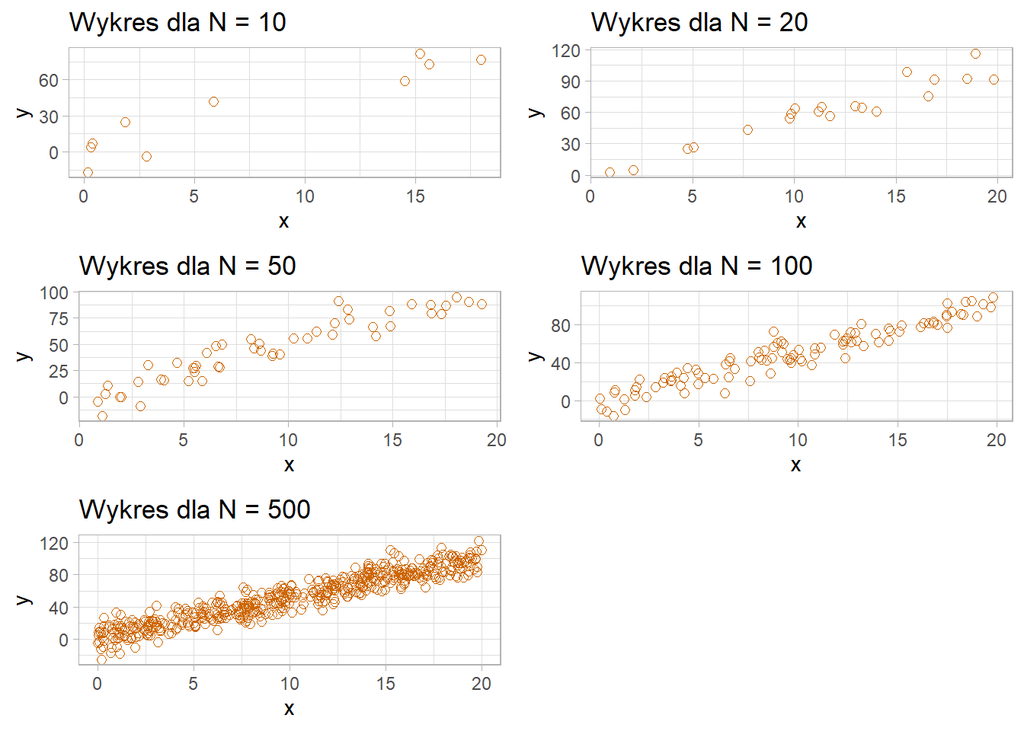

W tym wypadku odchylenie standrdowe jest wysokie, ponieważ wynosi 10. Widać bardzo wyraźną różnicę w porównaniu z przypadkiem pierwszym. Widać mocne “szumy”, obserwacje są rozproszone wokół prostej. Ponieważ k = 1, mamy do czynienia z homoscedastycznością, czyli wariancja składnika losowego jest zawsze taka sama. Z tego powodu nie widać różnicy w odchyleniu od prostej między pierwszą a drugą połową obserwacji.

**Przypadek 3**

- sigma = 1
- k = 10

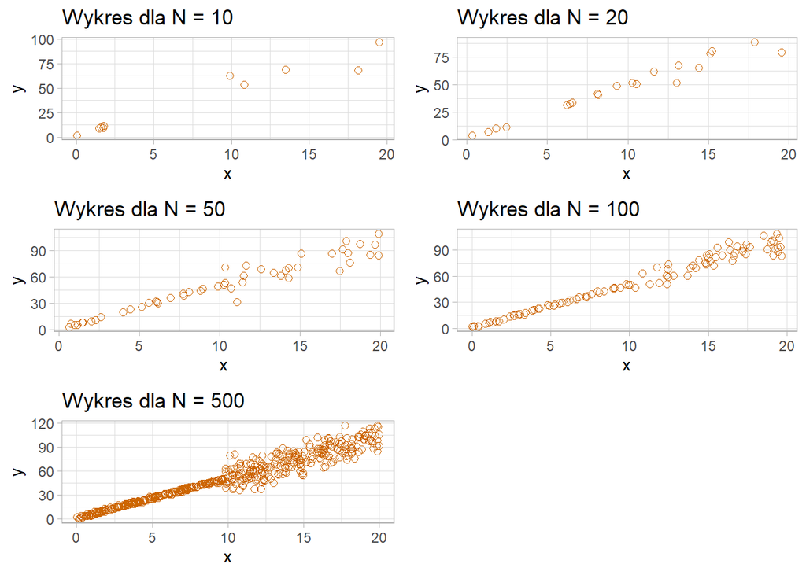

W powyższym przypadku mamy sytuację małego odchylenia standardowego, ale w drugiej połowie obserwacji jest ono przemnożone przez duży współczynnik k. Bardzo wyraźnie widać to na wykresach. Pierwsza połowa bardzo regularnie układa się w linię prostą, natomiast od drugiej połowy obserwacje są mocno rozproszone. Mamy do czynienia z heteroscedastycznością, ponieważ wariancja składników losowych nie jest taka sama dla wszystkich obserwacji.

**Przypadek 4**

- sigma = 10
- k = 10

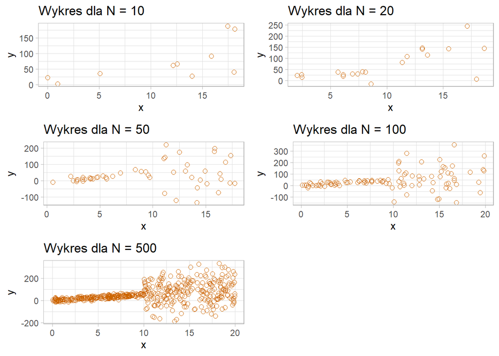

Ostatni przypadek pokazuje sytuację zarówno dla dużego odchylenia, jak i dużego współczynnika k. W pierwszej połowie obserwacje są lekko rozproszone wokół wykresu prostej, natomiast w drugiej połowie składniki losowe są przemnożone przez tak dużą wartość (100), że obserwacje są całkowicie rozproszone. Widać bardzo wyraźną różnicę między pierwszą a drugą połową obserwacji. Ponownie gołym okiem widać heteroscedastyczność.

# Wizualizacja rozkładów statystyk

Ta część projektu skupia się na zwizualizowaniu statystyk, które zostały obliczone wcześniej. Zastosowano do tego wykresy pudełkowe oraz krzywe gęstości. Celem jest pokazanie, jak zmiana różnych parametrów wpływa na rozkład.

## Rozkład statystyki a zmiana wielkośći próby

Wybrano ten rozkład, ponieważ zarówno paramter k, jak i sigma nie wprowadzają żadnych modyfikacji do rozkładu. Dzieki temu uzyskiwany jest lepszy obraz na zachodzące zmiany wraz ze wzrostem próbki badawczej.

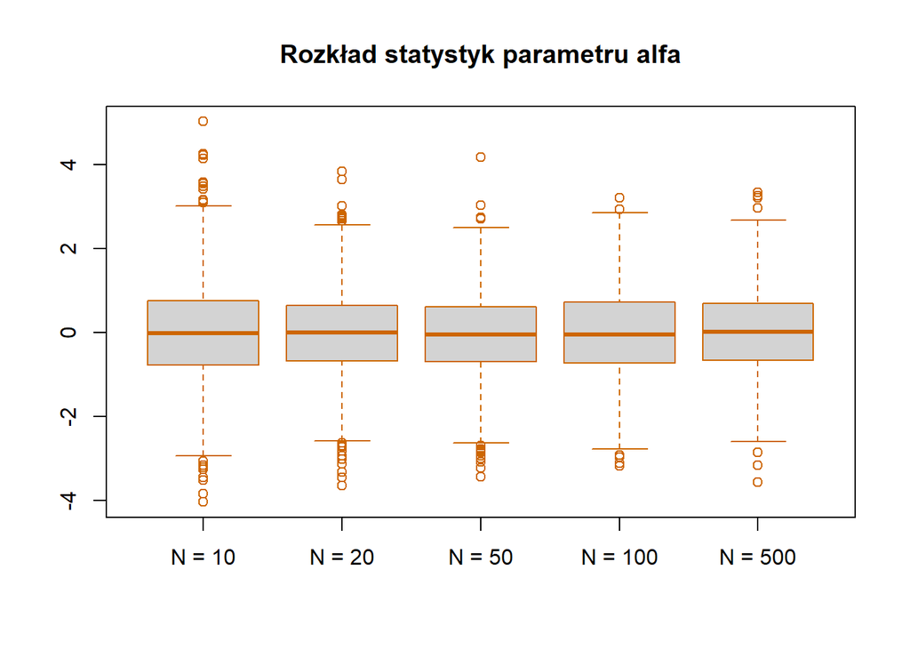

Ogólny kształt wykresów pudełkowych nie zmienia się znacząco wraz ze wzrostem liczby parametrów. Mediana zawsze wynosi około 0, także kwartyl pierwszy i trzeci są niemal równe. Szerokość pudełka (rozstęp ćwiartkowy) również jest bardzo podobna dla wszystkich przypadków. Rozkłady są symetryczne. Widać natomiast różnicę w ilości wartości odstających. Wraz ze wzrostem N outlierów jest coraz mniej.

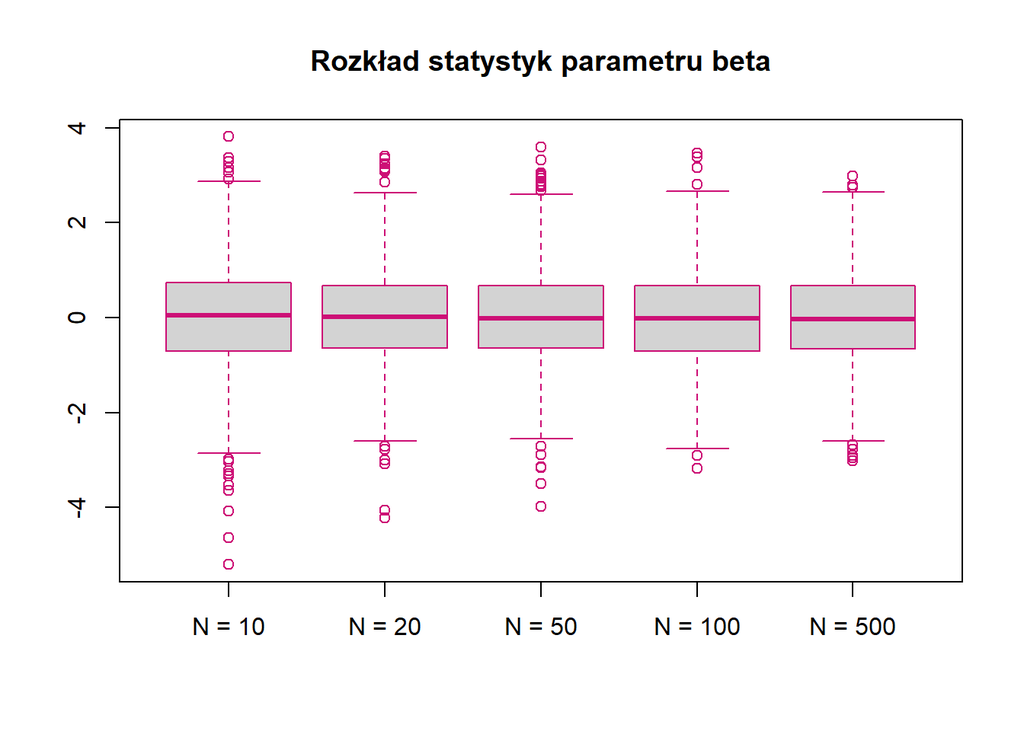

Analogicznie jak przy badaniu wyrazu wolnego, wszystkie pudełka są niemal jednakowe. Ponownie jedyną różnicą jest ilośc outlierów, któa jest wysoka dla małych N i spada wraz z ich zwiększaniem.

## Rozkład statystyki a zmiana przedziału i parametrów

W celu analizy zmian zachodzących pod wpływem zmian przedziału rozkładu jednostajnego oraz parametrów modelu regresji liniowej wybrano rozkłady o parametrach:

- k = 1
- sigma = 1
- n = 500

dla obydwóch badanych modeli oraz obydwóch rozważanych przedziałów.

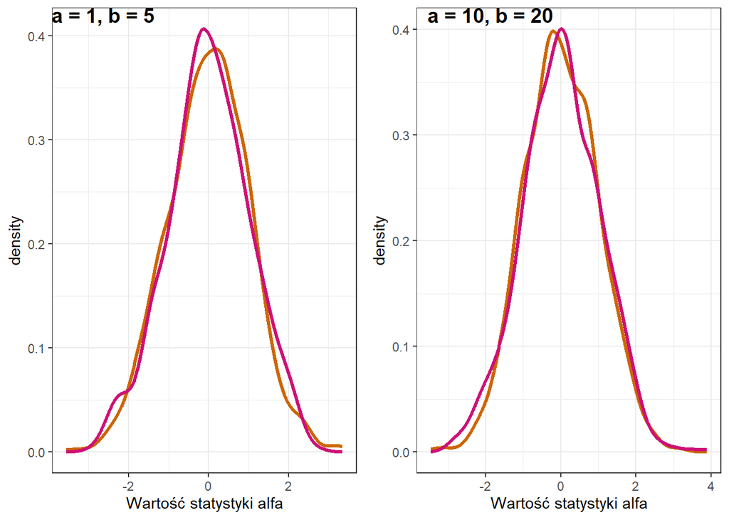

Kolorem pomarańczowym oznaczono przedział [0,20] natomiast różowym przedział [0, 200].  
Widać, że krzywe gęstości nie różnią między sobą znacząco ani ze względu na paramety, ani ze względu na przedział. Kształty krzywych gęstości są bardzo podobne, przypominające kształt rozkładu t-Studenta.

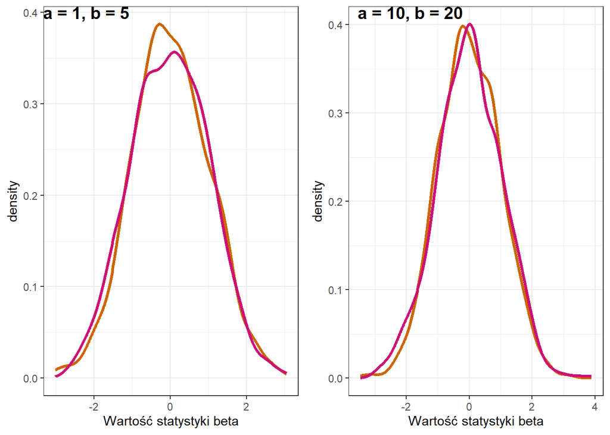

Kolorem pomarańczowym oznaczono przedział [0,20] natomiast różowym przedział [0, 200].  
Analogicznie jak w poprzednim przypadku, statystyki beta nie różnią się rozkładem ze względu na parametry lub zmianę przadziału. Ich kształt ponownie jest zbliżony do rozkładu t-Studenta. Jedyną zauważalną różnicą jest to, że krzywe gęstości są bardziej “wusmukłe” dla przypadku a=10, b=20.

## Rozkład statystyki a zmiana parametru k

Przez parametr k przemnażany jest składnik losowy εi dla i = N/2+1,…,N. Parametr k = 1 oznacza homoskedastyczność i jest to benchmark, do którego można odnosić inne wyniki. Przeciwieństwem do homoskedastyczności jest heteroskedastyczność, czyli zróżnicowanie w wariancji składnika losowego dla poszczególnych wartości zmiennej niezależnej.

Do przebadania zmian zachodzących w rozkładach statystych badanych parametrów wybrano rozkład o pramaterach:

- przedział [0:20]
- a = 10 , b = 20
- n = 500
- sigma = 1

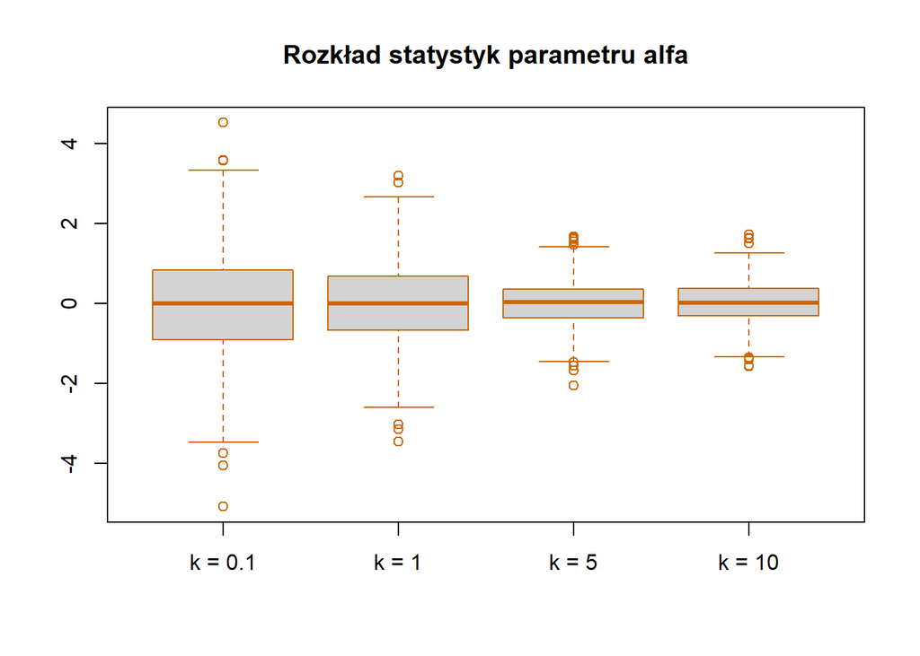

Wraz ze wzrostem k maleje szerokość pudełka (czyli zmniejsza się rozstęp ćwiartkowy - różnica między trzecim a pierwszym kwartylem). Rozkłady robią się coraz bardziej wysmukłe. Mediana nie zmienia się i zawsze wynosi około 0. Rozkłady zawsze są symetryczne, bez względu na wielkość k. Co ciekawe, mimo zmniejszania się rozstępu ćwiartkowego, nie maleje ilość outlierów.

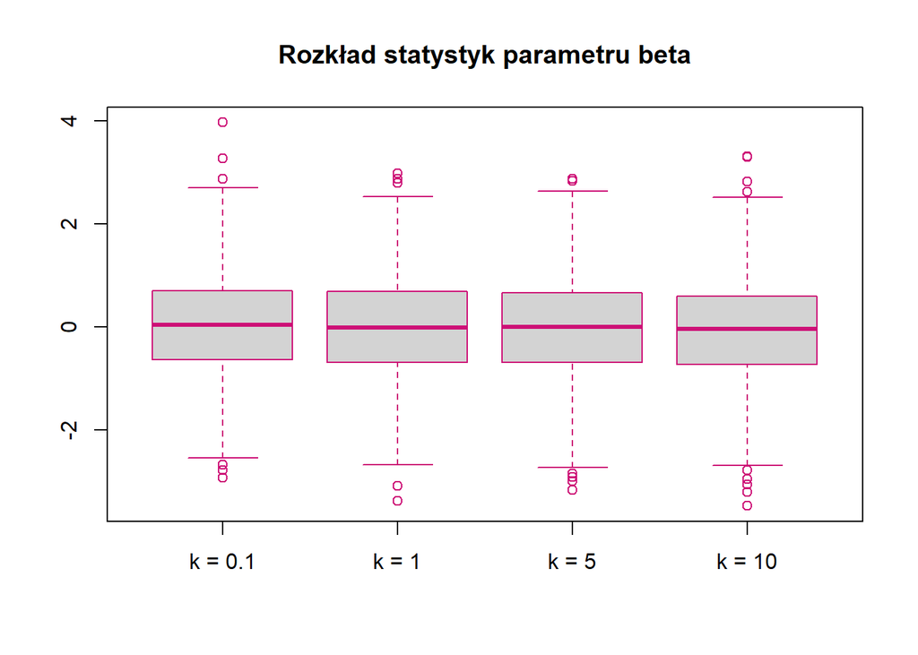

W przeciwieństwie do rozkładu parametru alfa, dla parametru beta nie widać gołym okiem zmian na wykresach pudełkowych. Zawórno mediana, rozstęp ćwiartkowy, symetria czy outliery zachowują się tak samo w przypadku wszystkich czterech przypadków k.

## Rozkład statystyki a zmiana parametru sigma

Przez parametr sigma ( przyjmujący 2 wartości : 1 oraz 10), przemnażana jest całość składnika losowego.

W celu przeanalizowania zmian zachodzących w rozkładach statystyk, wybrano rozkład o następujących parametrach:

- przedział [0:20]
- a = 10 , b = 20
- n = 500
- k = 1

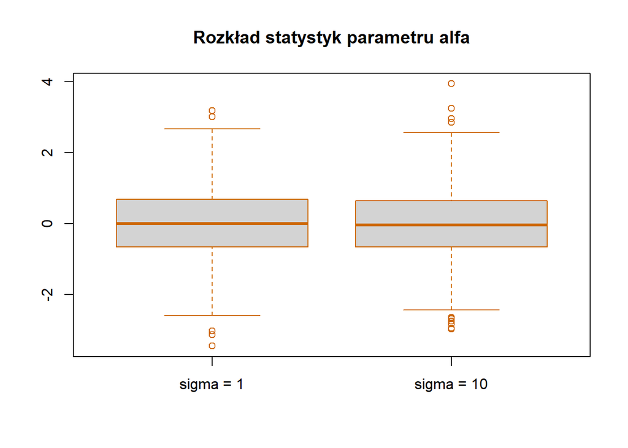

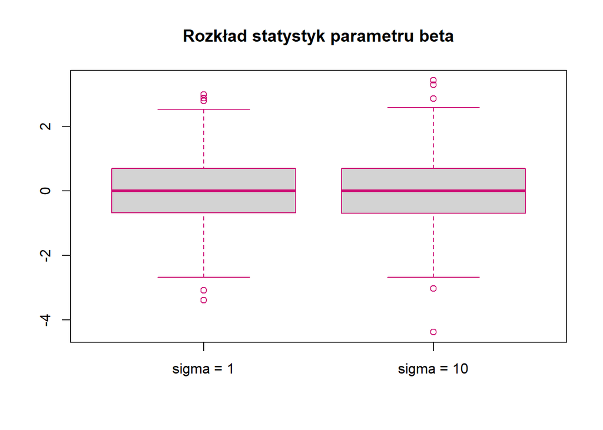

W obu przypadkach wielkośc sigmy nie ma znaczenia na rozkład statystyk. Są one symetryczne, mają podobną medianę i kwartyle oraz podobną ilość outlierów. Mimo, że mogłoby się wydawać, że odchylenie standardowe składnika losowego będzie mieć ogromny wpłw na wygląd rozkładu, jednak wizualizacje pokazują, że wcale tak nie jest.

# Badanie zgodności rozkładów z rozkładem t-Studenta

Ta część projektu skupia się na tym, żeby zbadać, czy zgodnie z teorią rozkłady statystyk faktycznie będa miały rozkład t-Studenta. Częściowo na to pytanie widać było odpowiedź na wykresach przedstawianych w poprzednim etapie projektu. Teraz jednak do sprawdzenia, czy wykres ma rozkład t-Studenta, zostanie wykorzystany test Kołmogorowa-Smirnowa.

**Hipoteza 0: Statystyki mają rozkład t-Studenta**

**Hipoteza 1: Statystyki nie mają rozkładu t-Studenta**

W tej częsci projektu zbadanie zostana zgodność rozkładu statystyk estymatorów z rozkładem t-Studenta (o liczbie stopni swobody n - (k+1) ) gdzie n to liczba obserwacji, a k to liczba zmiennych objaśniających bez stałej. We wszystkich testach przyjmowany jest poziom istotności α = 0.05.

Na sam poczatek przeprowadzono test Kołmogorowa_Smirnova dla wszytkich 320 badanych rozkładów statystyk. Wyniki badania zaprezentopwana w tabelach oraz na wykresie

Wyniki badania dla parametru beta:

[output not shown]

Wyniki badania dla parametru alfa:

|  | N = 10 | N = 20 | N = 50 | N = 100 | N = 500 |
| --- | --- | --- | --- | --- | --- |
| Nie | 49 | 48 | 48 | 48 | 49 |
| Tak | 15 | 16 | 16 | 16 | 15 |

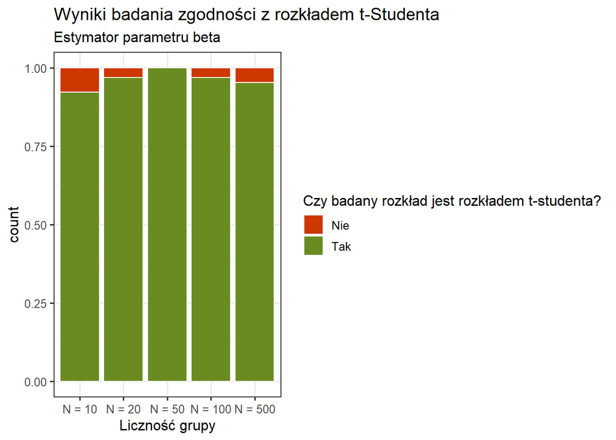

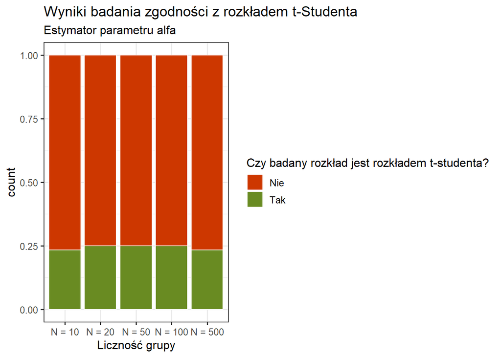

Wyniki w przypadku obydwóch tych parametrów diametralnie sie różnią. Spowodowane jest to faktem że 3/4 rozkładów zostało zmodyfikowane tak aby nie spełniały założenia homoskedastyczności, co przy badaniu rozkładów statystyk parametru alfa jest kluczowym założeniem. Brak tego założenia nie szczególnie wpłynął na wyniki dla rozkładu statystyk beta. błędów I rodzaju jest około 5% czyli tylke ile przewidują założenia prowadzonego testu(α = 0.05)

W kolejnej części postaramy się dodatkowo zweryfikować czy istnieją czynniki poza hetero/homoskedastycznością które wpłyneły na wyniki przeprowadzonego testu.

## Rozkład t-Studenta a zmiana wielkości próby

Dla rozkładu statystyk alfa:

|  | N = 10 | N = 20 | N = 50 | N = 100 | N = 500 |
| --- | --- | --- | --- | --- | --- |
| Wartość p-value | 0.15 | 0.69 | 0.6288 | 0.2933 | 0.5331 |
| Rozkład t-Studenta | Tak | Tak | Tak | Tak | Tak |

Dla rozkładu statystyk beta:

|  | N = 10 | N = 20 | N = 50 | N = 100 | N = 500 |
| --- | --- | --- | --- | --- | --- |
| Wartość p-value | 0.0691 | 0.5404 | 0.6667 | 0.8189 | 0.8012 |
| Rozkład t-Studenta | Tak | Tak | Tak | Tak | Tak |

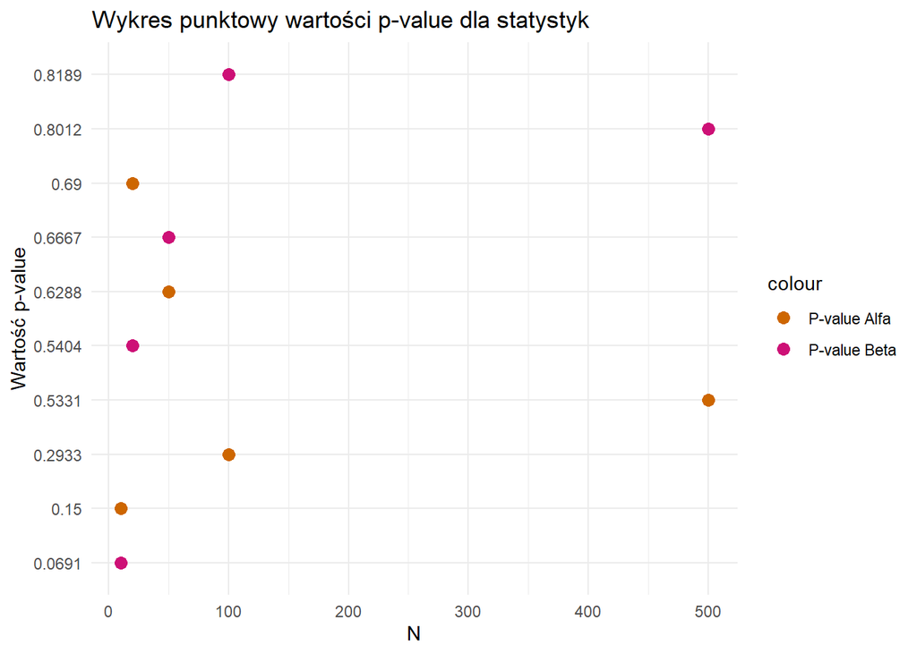

## Rozkład t-Studenta a zmiana przedziału

W tym przypadku badamy, jak zmiana przedziału, z którego losujemy wartości x w pierwszym kroku symulacji (z rozkładu jednostajnego) wpływa na to, czy statystyk zmiennej jest rozkładem t-Studenta.  
Do przebadania zmian zachodzących w rozkładach statystyk badanych parametrów wybrano rokzład o pramaterach:

- a = 1, b = 5
- k = 1
- sigma = 1
- n = 500

Dla rozkładu statystyk alfa:

|  | [0, 20] | [0, 200] |
| --- | --- | --- |
| Wartość p-value | 0.5332 | 0.9075 |
| Rozkład t-Studenta | Tak | Tak |

Dla rozkładu statystyk beta:

|  | [0, 20] | [0, 200] |
| --- | --- | --- |
| Wartość p-value | 0.8014 | 0.2583 |
| Rozkład t-Studenta | Tak | Tak |

## Rozkład t-Studenta a zmiana parametru k

W tym przypadku badamy, jak zmiana parametru k, przez który przemnażamy drugą połowę składników losowych (epsilon) wpływa na rozkład. Dla k = 1 mamy do czynienia z homoskedastycznością (benchmark, do którego odnosimy inne przypadki). Do przebadania zmian zachodzących w rozkładach statystyk badanych parametrów wybrano rozkład o pramaterach:

- przedział [0, 20]
- a = 10, b = 20
- sigma = 1
- n = 500

Dla rozkładu statystyk alfa:

|  | k = 0.1 | k = 1 | k = 5 | k = 10 |
| --- | --- | --- | --- | --- |
| Wartość p-value | 1e-04 | 0.9602 | 0 | 0 |
| Rozkład t-Studenta | Nie | Tak | Nie | Nie |

Dla rozkładu statystyk beta:

|  | k = 0.1 | k = 1 | k = 5 | k = 10 |
| --- | --- | --- | --- | --- |
| Wartość p-value | 0.7594 | 0.9998 | 0.796 | 0.1589 |
| Rozkład t-Studenta | Tak | Tak | Tak | Tak |

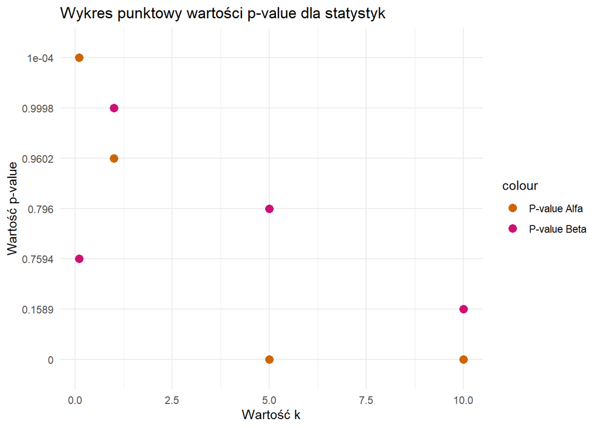

## Rozkład t-studenta a zmiana parametru sigma

W tym przypadku badamy, jak zmiana parametru sigma, przez który przemnażamy błędy losowych (epsilon) wpływa na normalność rozkładu.  
Do przebadania zmian zachodzących w rozkładach statystyk badanych parametrów wybrano rokzład o pramaterach:

- przedział [0, 20]
- a = 10, b = 20
- k = 1
- n = 500

Dla rozkładu statystyk alfa:

|  | sigma = 1 | sigma = 10 |
| --- | --- | --- |
| Wartość p-value | 0.9602 | 0.5101 |
| Rozkład t-Studenta | Tak | Tak |

Dla rozkładu statystyk beta:

|  | sigma = 1 | sigma = 10 |
| --- | --- | --- |
| Wartość p-value | 0.9998 | 0.9775 |
| Rozkład t-Studenta | Tak | Tak |

Wyniki testu kołgomorowa-smirnowa pokazują, że rozkłady statystyk mają praktycznie zawsze rozkład t-Studenta o liczbie n - (k+1) stopni swobody gdy spełniony zostaje warunek homoskedastyczności. Zmiany parametrów: wielkości próby, sigmy czy zmiany przedziału nie wpłynęły na wyniki testów i w żadnym z tych przypadków nie odrzucamy hipotezy H0 zarówno dla statystyki alfa, jak i beta w więcej niż 5 % przypadków. Jedyne zauważalne odstępstwo w rozkładach statystyki alfa pojawia się w przypadku zmiany parametru k. Tylko w przypadku gdy mamy doczynienia z homoskedastycznością (k = 1) mamy zgodność z rozkładem t-Studenta. Przemnożenie drugiej połowy składników losowych spowodowało, że odrzuciliśmy hipotezę zerową, ponieważ pojawiła sie nie pożądana cecha czyli heteroskedastyczność. Co ciekawe, zmiany tego parametru nie wpłynęły na rozklad statystyki beta. Ta statystyka ma zawsze rozkład t-Studenta, bez względu na zmiany parametrów.

# Podsumowanie

Analiza rozkładów statystyk alfa i beta oraz testu Kołmogorowa-Smirnowa w zależności od różnych parametrów wykazały, że homoskedastyczne rozkłady statystyk mają praktycznie zawsze rozkład t-Studenta o liczbie n - (k+1) stopni swobody, co potwierdza zgodność z teorią. Największy wpływ miała jedynie zmiana parametru k na rozkład statystyki alfa. Zwiększanie parametru k (odpowiadającego za heteroskedastyczność) prowadziło do zmniejszenia rozstępu ćwiartkowego i “wysmuklenia” rozkładów. W teście Kołgomorowa-Smirnowa spowodował odrzucenie hipotezy zerowej, że statystyka alfa ma rozkład t-Studenta. Podsumowując, zmiany parametrów nie wpływają znacząco na rozkład statystyki beta, ma ona zawsze rozkład t-Studenta, co można zaobserwować zarówno na wizualizacjach jak i w wynikach testu zgodności. Natomiast statystyka alfa, jedynie w sytuacji, gdy występowała heteroskedastyczność (parametr k różny od 1), nie miała rozkładu t-Studenta. W każdym innym przypadku miałą ona ten rozkład. Badanie wykazało jak ważne jest spełnienie założeń w badaniu.